# Duwaerts and Mattis RNA-seq human iPSC lines

Tara Friedrich

2/19/2019

```r
library(pheatmap)
library(edgeR)
library(DESeq2)
library(biomaRt)
library(ggplot2)
library(topGO)
require(plyr)
library(GOplot)
library("org.Hs.eg.db")
```

Read in files with read counts.

```r
filename1 = "~/Downloads/readcounts1.txt"
filename2 = "~/Downloads/readcounts2.txt"
filename3 = "~/Downloads/readcounts3.txt"

counts1 = read.table(filename1, header = T, stringsAsFactors = F)
counts2 = read.table(filename2, header = T, stringsAsFactors = F)
counts3 = read.table(filename3, header = T, stringsAsFactors = F)

counts = cbind(counts1, counts2, counts3)
dim(counts)
```

```
## [1] 58302    56
```

```r
rownames(counts) = counts1$Geneid
```

Remove metadata (Gene, coordinates, etc)

```r
counts_matrix = data.matrix(counts[,grep ("bam", colnames(counts))])
#colnames(counts_matrix) = sub("_1_algn_Aligned", "", matrix(unlist(strsplit(colnames(counts_matrix), "\\.")), byrow =T, ncol=6)[,3])
colnames(counts_matrix) = matrix(unlist(strsplit(colnames(counts_matrix), "algn.")), byrow =T, ncol=3)[,2]
#rename to reflect useful labels
key1 = read.table("~/Downloads/Mattis_Duwaerts_metadata2.txt", header = T, stringsAsFactors = F, fill=T, sep="\t")
head(key1)
```

```
##            FILE.NAME CELL.TYPE DISEASE.STATUS FULL.SAMPLE.ID
## 1  1_S1_R1_001.fastq iPSC-PBMC        HEALTHY        CW10001
## 2  2_S2_R1_001.fastq iPSC-PBMC        HEALTHY        CW10002
## 3  7_S3_R1_001.fastq iPSC-PBMC           NASH        CW10007
## 4 12_S4_R1_001.fastq iPSC-PBMC           NASH        CW10012
## 5 15_S5_R1_001.fastq iPSC-PBMC           NAFL        CW10015
## 6 20_S6_R1_001.fastq iPSC-PBMC           NASH        CW10020
##   OUTLIERS.PRIOR.ANALYSES
## 1
## 2
## 3
## 4
## 5
## 6                       X
```

```r
key2 = read.table("~/Downloads/Mattis_Duwaerts_metadata.txt", header = T, stringsAsFactors = F, fill=T, sep="\t")
head(key2)
```

```
##                                                                                                                 Location
## 1  /Volumes/My Passport/F17FTSUSAT0552_HUMyhuR/CleanData/AM_2/170924_I91_CL100029964_L2_HK500HUMyhuRAABRAAPEI-21_1.fq.gz
## 2  /Volumes/My Passport/F17FTSUSAT0552_HUMyhuR/CleanData/AM_3/170924_I91_CL100029964_L2_HK500HUMyhuRAACRAAPEI-22_1.fq.gz
## 3  /Volumes/My Passport/F17FTSUSAT0552_HUMyhuR/CleanData/AM_4/170924_I91_CL100029964_L2_HK500HUMyhuRAADRAAPEI-23_1.fq.gz
## 4 /Volumes/My Passport/F17FTSUSAT0552_HUMyhuR/CleanData/AM_43/170924_I89_CL100030081_L2_HK500HUMyhuRABMRAAPEI-17_1.fq.gz
## 5  /Volumes/My Passport/F17FTSUSAT0552_HUMyhuR/CleanData/AM_5/170924_I91_CL100029964_L2_HK500HUMyhuRAAERAAPEI-24_1.fq.gz
## 6  /Volumes/My Passport/F17FTSUSAT0552_HUMyhuR/CleanData/AM_6/170924_I91_CL100029964_L2_HK500HUMyhuRAAFRAAPEI-25_1.fq.gz
##    X X.1 X.2 X.3 X.4 X.5 X.6 X.7 X.8 X.9      Name cell.type  Genotype
## 1 NA  NA  NA  NA  NA  NA  NA  NA  NA  NA    7017-5       iPS   NASH pt
## 2 NA  NA  NA  NA  NA  NA  NA  NA  NA  NA    7017-6       iPS   NASH pt
## 3 NA  NA  NA  NA  NA  NA  NA  NA  NA  NA   4484-12       iPS   NASH pt
## 4 NA  NA  NA  NA  NA  NA  NA  NA  NA  NA GM01708-3       iPS wild-type
## 5 NA  NA  NA  NA  NA  NA  NA  NA  NA  NA   CW10054       iPS wild-type
## 6 NA  NA  NA  NA  NA  NA  NA  NA  NA  NA    7192-7       iPS   NASH pt
##   dox.treatment.Volumes.My.Passport.F17FTSUSAT0552_HUMyhuR.CleanData.AM_1.170924_I91_CL100029964_L2_HK500HUMyhuRAAARAAPEI.20_1.fq.gz
```

[output cut: 20 more lines]

```r
renamesample=list()
for (x in 1:nrow(key1  )){
  oldname = paste0(sub(".fastq", "", key1$FILE.NAME[x], "_"), "_")
  #print (key1$CELL.TYPE[x])  #check to make sure every sample is endoderm
  newname = paste(key1$FULL.SAMPLE.ID[x], key1$CELL.TYPE[x], key1$DISEASE.STATUS[x], "CD", sep="_")
  renamesample[oldname] = newname
}
for (x in 1:nrow(key2)){
  oldname = paste0(sub("-", ".", sub(".fq.gz", "", matrix(unlist(strsplit( key2$Location[x], "/")), byrow=T, ncol=7)[,7])), "_")
  #print (key2$cell.type[x])  #check to make sure every sample is endoderm
  newname = paste(key2$Name[x], key2$cell.of.origin[x], key2$Genotype[x], "AM", sep="_")
  renamesample[oldname] = newname
}

colnames(counts_matrix) = unlist(lapply (colnames(counts_matrix), function(x) renamesample[[x]]))
colnames(counts_matrix) = sub ("NASH pt", "NASH", colnames(counts_matrix))
colnames(counts_matrix) = sub ("wild-type", "HEALTHY", colnames(counts_matrix))

if (colnames(counts_matrix)[21] == colnames(counts_matrix)[22]) {
  colnames(counts_matrix)[21] = "CW10027_iPSC-PBMC_HEALTHY_CDa"
  colnames(counts_matrix)[22] = "CW10027_iPSC-PBMC_HEALTHY_CDb"
}
colnames(counts_matrix)[grep ("WBC", colnames(counts_matrix))] = c("CW10054_iPSC-PBMC_HEALTHY_AM", "CW10007_iPSC-PBMC_NASH_AM" )
```

Filter out genes that are too highly expressed or lowly expressed.

```r
keep = rowMeans(counts_matrix) > 5 & rowMeans(counts_matrix) < 5000
counts_matrix_filtered = counts_matrix[keep,]
```

Take the RPKM.

```r
y <- DGEList(counts=counts_matrix_filtered)
fpkm_matrix = rpkm (y, gene.length=counts1[keep,"Length"], log = FALSE)
```

Dendrogram showing relationships using fpkm. Mattis’ PBMCs do not cluster with Caroline’s even though two of them come from the same patient. CW10027 samples do not cluster together. CW10020, CW10022 and CW10054 were listed as outliers prior to analysis but they don’t seem to be behaving oddly.

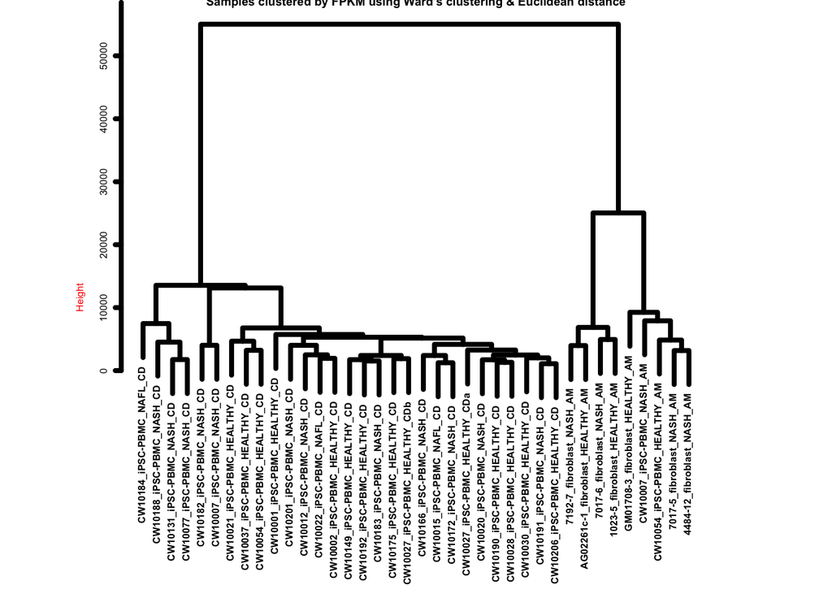

```r
par(cex=.5,font=2)
hc2 <- hclust(stats::dist(t(fpkm_matrix), method="minkowski"), "ward.D2")
par(mar=c(.2,.2,.2,.2), pty='s')
plot(hc2, lwd=4, lty=1, col="black", col.lab="red", xlab="Samples", main="Samples clustered by FPKM using Ward's clustering & Euclidean distance")
```

label each sample by three conditions 1) cell origin 2) disease status 3) patient source

```r
CellType = factor(matrix (unlist(strsplit(colnames(counts_matrix_filtered), "_")), byrow=T, ncol=4)[,2], levels = c("iPSC-PBMC", "fibroblast"))
DiseaseStatus = factor(matrix (unlist(strsplit(colnames(counts_matrix_filtered), "_")), byrow=T, ncol=4)[,3], levels = c("HEALTHY","NASH", "NAFL"))
SampleID = factor(matrix (unlist(strsplit(colnames(counts_matrix_filtered), "_")), byrow=T, ncol=4)[,1])
Lab = factor(matrix (unlist(strsplit(colnames(counts_matrix_filtered), "_")), byrow=T, ncol=4)[,4])
```

log transformation for PCA plot

```r
cold <- data.frame("CellType"=CellType)
rownames(cold) = colnames(counts_matrix_filtered)
cold
```

```
##                                    CellType
## CW10184_iPSC-PBMC_NAFL_CD         iPSC-PBMC
## CW10188_iPSC-PBMC_NASH_CD         iPSC-PBMC
## CW10190_iPSC-PBMC_HEALTHY_CD      iPSC-PBMC
## CW10191_iPSC-PBMC_NASH_CD         iPSC-PBMC
## CW10192_iPSC-PBMC_HEALTHY_CD      iPSC-PBMC
## CW10201_iPSC-PBMC_NASH_CD         iPSC-PBMC
## CW10206_iPSC-PBMC_HEALTHY_CD      iPSC-PBMC
## CW10012_iPSC-PBMC_NASH_CD         iPSC-PBMC
## CW10131_iPSC-PBMC_NASH_CD         iPSC-PBMC
## CW10149_iPSC-PBMC_HEALTHY_CD      iPSC-PBMC
## CW10015_iPSC-PBMC_NAFL_CD         iPSC-PBMC
## CW10166_iPSC-PBMC_NASH_CD         iPSC-PBMC
## CW10172_iPSC-PBMC_NASH_CD         iPSC-PBMC
## CW10175_iPSC-PBMC_HEALTHY_CD      iPSC-PBMC
## CW10182_iPSC-PBMC_NASH_CD         iPSC-PBMC
## CW10183_iPSC-PBMC_NASH_CD         iPSC-PBMC
## CW10001_iPSC-PBMC_HEALTHY_CD      iPSC-PBMC
## CW10020_iPSC-PBMC_NASH_CD         iPSC-PBMC
## CW10021_iPSC-PBMC_HEALTHY_CD      iPSC-PBMC
## CW10022_iPSC-PBMC_NAFL_CD         iPSC-PBMC
## CW10027_iPSC-PBMC_HEALTHY_CDa     iPSC-PBMC
## CW10027_iPSC-PBMC_HEALTHY_CDb     iPSC-PBMC
## CW10028_iPSC-PBMC_HEALTHY_CD      iPSC-PBMC
## CW10002_iPSC-PBMC_HEALTHY_CD      iPSC-PBMC
## CW10030_iPSC-PBMC_HEALTHY_CD      iPSC-PBMC
## CW10037_iPSC-PBMC_HEALTHY_CD      iPSC-PBMC
## CW10054_iPSC-PBMC_HEALTHY_CD      iPSC-PBMC
## CW10077_iPSC-PBMC_NASH_CD         iPSC-PBMC
## CW10007_iPSC-PBMC_NASH_CD         iPSC-PBMC
## GM01708-3_fibroblast_HEALTHY_AM  fibroblast
## 7017-5_fibroblast_NASH_AM        fibroblast
## 7017-6_fibroblast_NASH_AM        fibroblast
## 4484-12_fibroblast_NASH_AM       fibroblast
## CW10054_iPSC-PBMC_HEALTHY_AM      iPSC-PBMC
## 7192-7_fibroblast_NASH_AM        fibroblast
## 1023-5_fibroblast_HEALTHY_AM     fibroblast
## AG02261c-1_fibroblast_HEALTHY_AM fibroblast
## CW10007_iPSC-PBMC_NASH_AM         iPSC-PBMC
```

```r
ddsMat <- DESeq2::DESeqDataSetFromMatrix(countData=counts_matrix_filtered, colData=cold, design=~CellType );
```

```
##   Note: levels of factors in the design contain characters other than
##   letters, numbers, '_' and '.'. It is recommended (but not required) to use
##   only letters, numbers, and delimiters '_' or '.', as these are safe characters
##   for column names in R. [This is a message, not an warning or error]
```

```r
colnames(ddsMat) <- colnames(counts_matrix_filtered)
rld <- DESeq2::rlog(ddsMat) # LOG TRANSFORMED.
```

```
## rlog() may take a few minutes with 30 or more samples,
## vst() is a much faster transformation
##   Note: levels of factors in the design contain characters other than
##   letters, numbers, '_' and '.'. It is recommended (but not required) to use
##   only letters, numbers, and delimiters '_' or '.', as these are safe characters
##   for column names in R. [This is a message, not an warning or error]
```

run PCA to explore structure in the data in lower dimensions.

```r
par(mfrow=c(2,1))
pca <- prcomp(t(assay(rld)))
```

Plot PC1 against PC2 using variance stabilizing transformation.

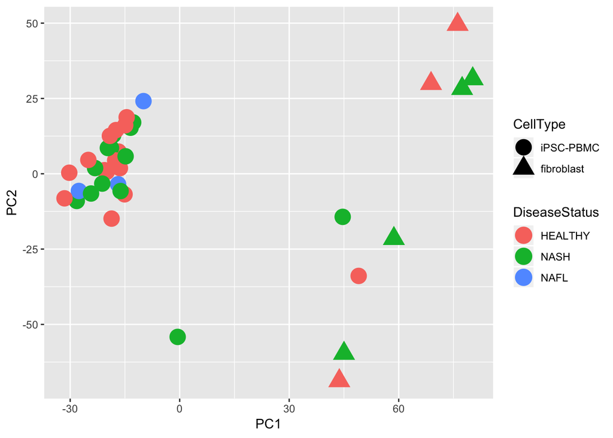

```r
d <- data.frame(pca$x, CellType, DiseaseStatus,  name=colnames(rld)) # returns PC1, PC2, ... PC8... etc
ppp <- ggplot(d, aes_string(x="PC1", y="PC2",shape="CellType", color="DiseaseStatus"))
ppp <- ppp + geom_point(size=6)
plot(ppp)
```

Plot PC1 against PC2 using variance stabilizing transformation.

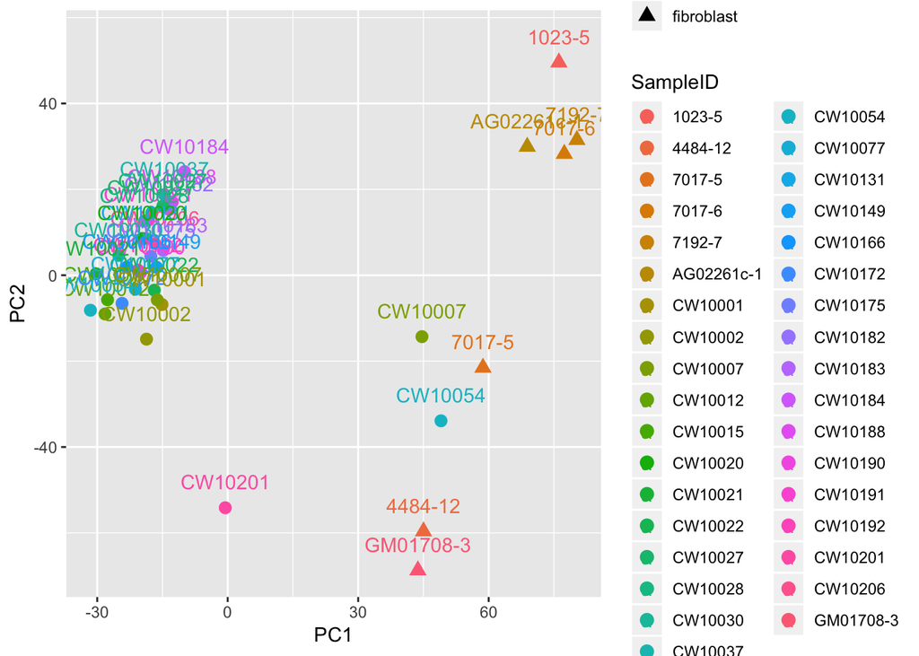

```r
d <- data.frame(pca$x, group=CellType, SampleID,  name=colnames(rld)) # returns PC1, PC2, ... PC8... etc
ppp <- ggplot(d, aes_string(x="PC1", y="PC2",shape="CellType", color="SampleID"))
ppp <- ppp + geom_point(size=3) + geom_text(aes(label=SampleID), nudge_y=6)
plot(ppp)
```

Some of the related samples are messing up clustering.

Plot PC1 against PC2 using variance stabilizing transformation.

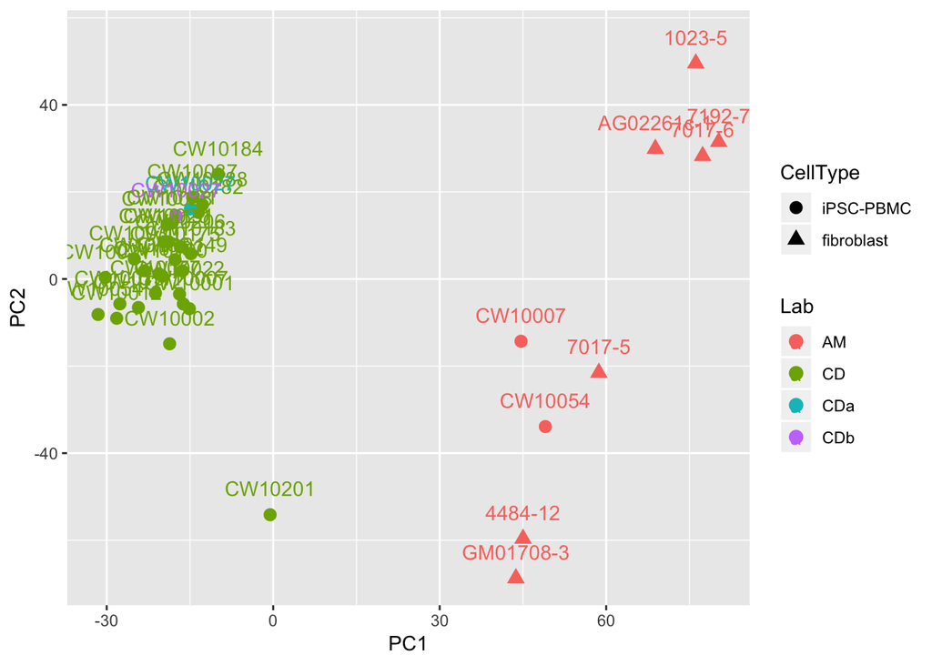

```r
d <- data.frame(pca$x, group=CellType, SampleID,  name=colnames(rld)) # returns PC1, PC2, ... PC8... etc
ppp <- ggplot(d, aes_string(x="PC1", y="PC2",shape="CellType", color="Lab"))
ppp <- ppp + geom_point(size=3) + geom_text(aes(label=SampleID), nudge_y=6)
plot(ppp)
```

Plot PC1 against PC2 using FPKM.

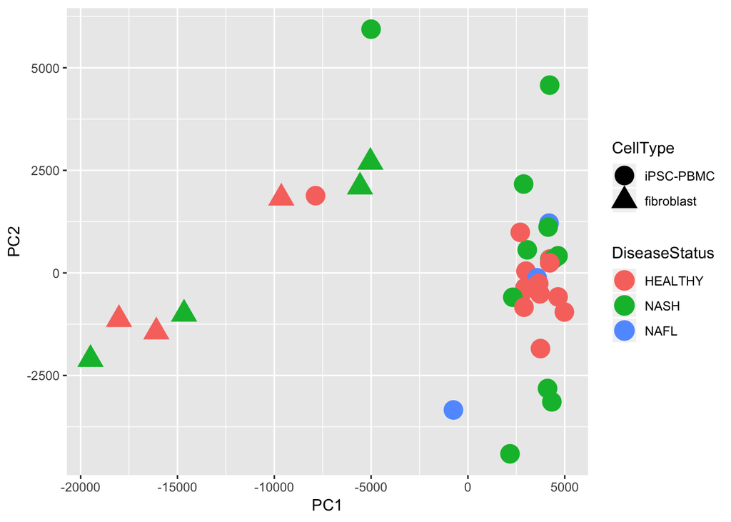

```r
pca_fpkm <- prcomp(t(fpkm_matrix))
d <- data.frame(pca_fpkm$x, CellType, DiseaseStatus,  name=colnames(fpkm_matrix)) # returns PC1, PC2, ... PC8... etc
ppp <- ggplot(d, aes_string(x="PC1", y="PC2",shape="CellType", color="DiseaseStatus"))
ppp <- ppp + geom_point(size=6)
plot(ppp)
```

Plot PC1 against PC2 using FPKM.

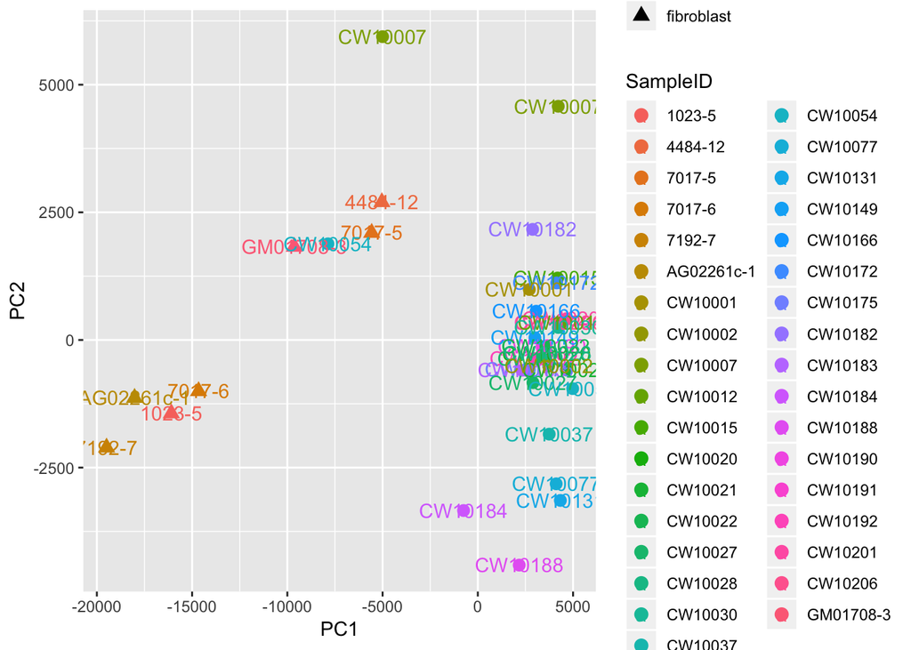

```r
d <- data.frame(pca_fpkm$x, group=CellType, SampleID,  name=colnames(fpkm_matrix)) # returns PC1, PC2, ... PC8... etc
ppp <- ggplot(d, aes_string(x="PC1", y="PC2",shape="CellType", color="SampleID"))
ppp <- ppp + geom_point(size=3) + geom_text(aes(label=SampleID), nudge_y=6)
plot(ppp)
```

Plot PC1 against PC2 using FPKM.

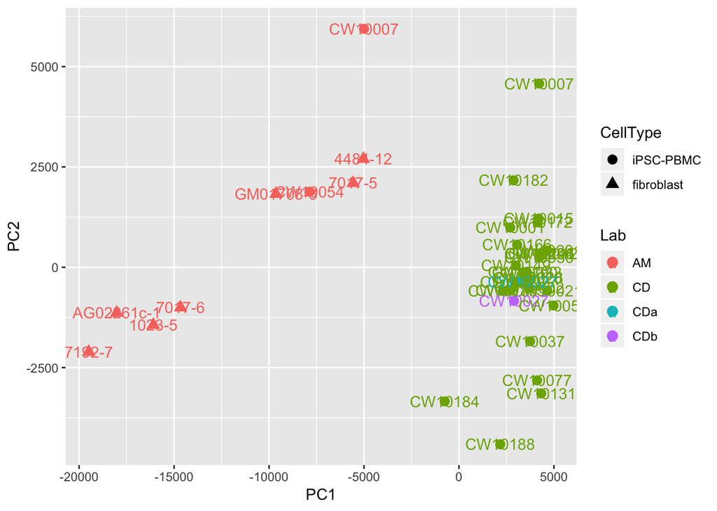

```r
d <- data.frame(pca_fpkm$x, group=CellType, SampleID,  name=colnames(fpkm_matrix)) # returns PC1, PC2, ... PC8... etc
ppp <- ggplot(d, aes_string(x="PC1", y="PC2",shape="CellType", color="Lab"))
ppp <- ppp + geom_point(size=3) + geom_text(aes(label=SampleID), nudge_y=6)
plot(ppp)
```

Heatmap to see how cells cluster by cell type or experimental condition. Does it agree with dendrogram which uses different clustering methods.

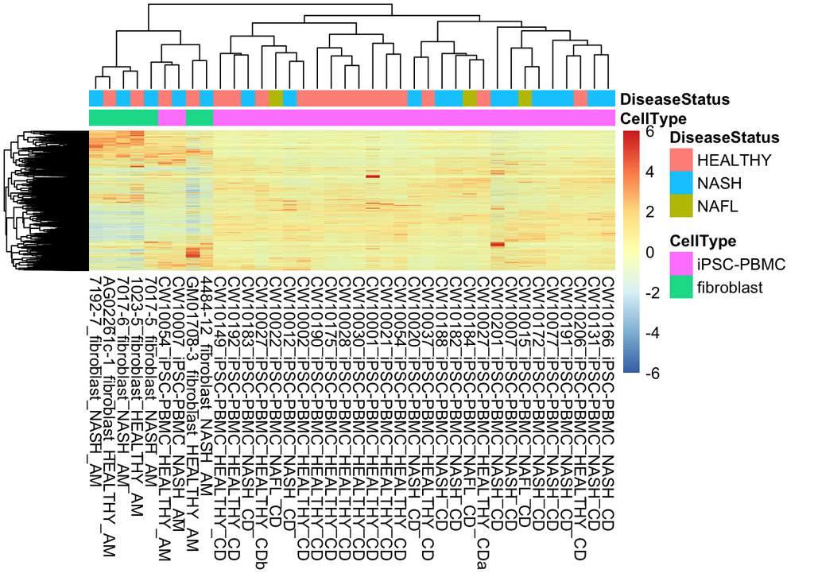

```r
HEATMAP_HEIGHT <- 45 # inchescol
HEATMAP_WIDTH  <- 15
annotation <- data.frame(
  CellType= CellType, DiseaseStatus=DiseaseStatus)
rownames(annotation) <- colnames(fpkm_matrix)
pheatmap(fpkm_matrix,
         , width=HEATMAP_WIDTH, height=HEATMAP_HEIGHT
         , scale="row"  # actually scale each row
         , clustering_distance_rows="correlation" # or: euclidean
         , clustering_distance_cols="correlation"
         , clustering_method="complete"
         , display_numbers=FALSE
         , border_color="#00000000" # note: the last two digits here are the alpha channel/ transparency
         , show_rownames=FALSE, show_colnames = TRUE
         , annotation = annotation
         , fontsize_row=3.5)
```

Fit the model and estimate dispersion value. Baseline is PBMC.

```r
design_matrix <- model.matrix( ~ CellType  )
colnames(design_matrix)
```

```
## [1] "(Intercept)"        "CellTypefibroblast"
```

```r
design_matrix
```

```
##    (Intercept) CellTypefibroblast
## 1            1                  0
## 2            1                  0
## 3            1                  0
## 4            1                  0
## 5            1                  0
## 6            1                  0
## 7            1                  0
## 8            1                  0
## 9            1                  0
## 10           1                  0
## 11           1                  0
## 12           1                  0
## 13           1                  0
## 14           1                  0
```

[output cut: 29 more lines]

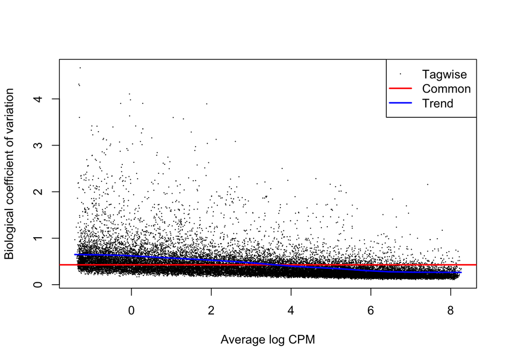

```r
y_for_DE <- DGEList(counts=counts_matrix_filtered)
y_for_DE <- calcNormFactors(y_for_DE)
y_for_DE = estimateDisp(y_for_DE, design=design_matrix)
plotBCV(y_for_DE)
```

```r
fit <- glmFit(y_for_DE, design=design_matrix, dispersion=y_for_DE$trended.dispersion)
```

Pretty high estimated dispersion values.

Fibroblast vs PBMC

```r
lrt <- glmLRT(fit, coef = "CellTypefibroblast")
topTags(lrt)
```

```
## Coefficient:  CellTypefibroblast
##                    logFC   logCPM        LR        PValue           FDR
## ENSG00000124785 6.305000 4.802655 1071.7734 4.506671e-235 1.188815e-230
## ENSG00000225616 4.233117 6.889227  935.6617 1.736058e-205 2.289774e-201
## ENSG00000267924 3.649589 6.639450  670.9375 6.247733e-148 5.493632e-144
## ENSG00000226624 4.190348 5.529965  635.8533 2.665550e-140 1.757864e-136
## ENSG00000258613 3.543725 6.448300  616.7741 3.761604e-136 1.984547e-132
## ENSG00000244527 3.419697 7.016062  613.6413 1.806222e-135 7.941053e-132
## ENSG00000235175 3.141288 7.304602  519.5376 5.335195e-115 2.010530e-111
## ENSG00000239412 4.168903 4.906876  516.3114 2.685663e-114 8.855639e-111
## ENSG00000273189 3.765470 5.530294  512.5192 1.795191e-113 5.261705e-110
## ENSG00000213750 3.170436 6.703225  503.0369 2.075906e-111 5.476033e-108
```

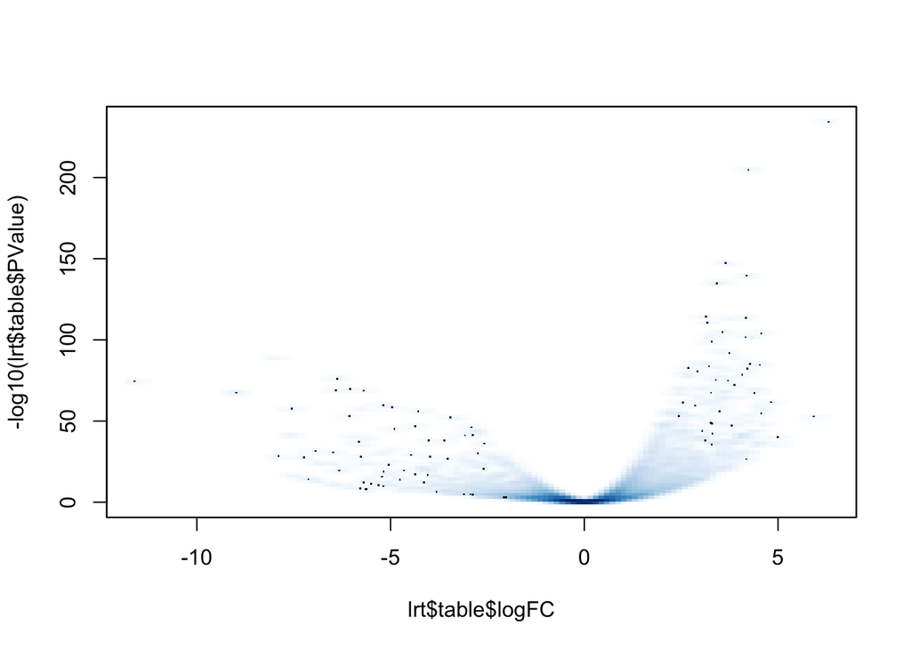

```r
smoothScatter(x=lrt$table$logFC, y=-log10(lrt$table$PValue))
```

Histogram should skew left. Things look super significant here but that is probably due to differences in batch rather than differences betwen fibroblast cell origin and PBMC cell origin.

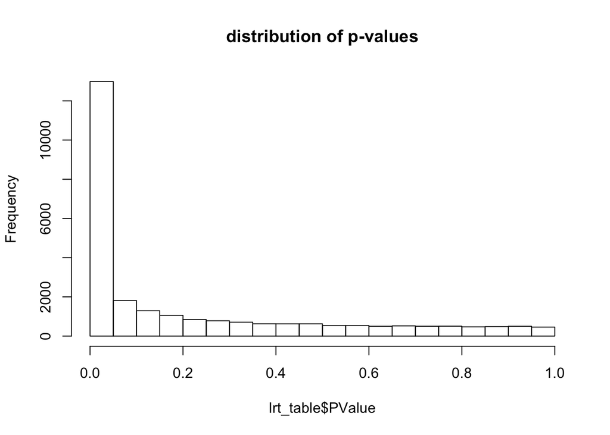

```r
lrt_table = data.frame(lrt$table, p.adjust(lrt$table$PValue, method = "BH"))
colnames(lrt_table) = c(colnames(lrt$table), "adjPVal_BH")
hist(lrt_table$PValue, main="distribution of p-values")
```

Format output into excel sheet.

```r
genes = rownames(counts_matrix_filtered)
ensembl = useEnsembl(biomart="ensembl", dataset="hsapiens_gene_ensembl",host="www.ensembl.org")
head(listAttributes(ensembl), 30)
```

```
##                               name
## 1                  ensembl_gene_id
## 2          ensembl_gene_id_version
## 3            ensembl_transcript_id
## 4    ensembl_transcript_id_version
## 5               ensembl_peptide_id
## 6       ensembl_peptide_id_version
## 7                  ensembl_exon_id
## 8                      description
## 9                  chromosome_name
## 10                  start_position
## 11                    end_position
## 12                          strand
## 13                            band
## 14                transcript_start
```

[output cut: 47 more lines]

```r
hgnc_swissprot <- getBM(attributes=c('ensembl_gene_id','hgnc_symbol','description'),filters = 'ensembl_gene_id',  values = genes , mart = ensembl)

index = match (genes, hgnc_swissprot$ensembl_gene_id)
results = data.frame(hgnc_swissprot[index,], counts_matrix_filtered, fpkm_matrix, lrt_table)
colnames(results) = c(
                    colnames(hgnc_swissprot[index,])
                  , unlist(lapply (colnames(counts_matrix_filtered), function(x) paste(x, "counts", sep="_")))
                  , unlist(lapply (colnames(fpkm_matrix), function(x) paste(x, "fpkm", sep="_")))
                  , unlist(lapply (colnames(lrt_table), function(x) paste(x, "_fibroblast_vs_pbmc_baseline", sep="_")))
                  )
curr_date = format(Sys.time(), "%a_%b_%d_%H_hrs_%M_min_%S_sec_%Y")
write.table(results, paste0("~/Downloads/duwaerts_mattis_de_", curr_date, ".xls"), row.names=rownames(counts_matrix_filtered), col.names=NA, sep="\t")
```

Differentially expressed genes shown using the expected (aka mean) values from the fitted model.

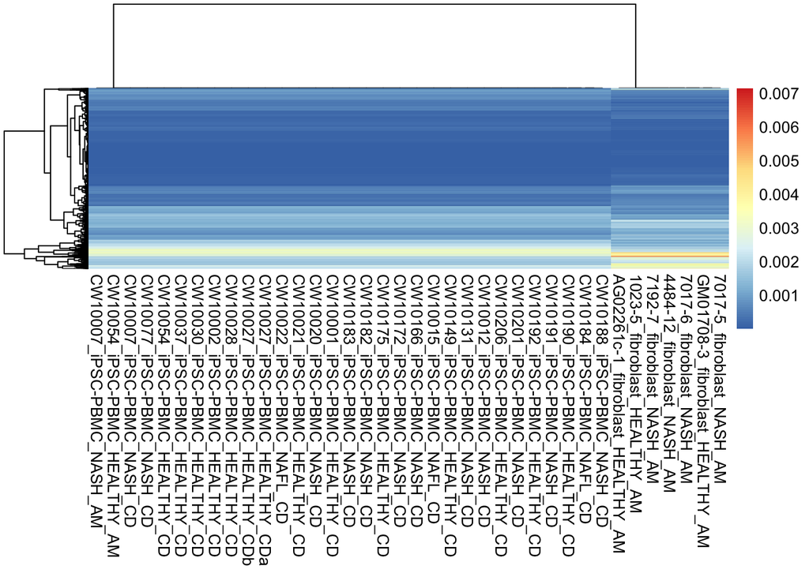

```r
mean_values = 2^((fit$coefficients) %*% t(design_matrix) )
colnames(mean_values) = colnames (counts_matrix_filtered)

de_mean_values = mean_values[rownames(mean_values) %in%  results[which(results[,"adjPVal_BH__fibroblast_vs_pbmc_baseline"] <=0.05),"ensembl_gene_id"], ]
pheatmap(de_mean_values,
         , width=HEATMAP_WIDTH, height=HEATMAP_HEIGHT
         #, scale="row"  # actually scale each row
         #, clustering_distance_rows="correlation" # or: euclidean
         , clustering_distance_cols="correlation"
         , clustering_method="complete"
         , display_numbers=FALSE
        , border_color="#00000000" # note: the last two digits here are the alpha channel/ transparency
         , show_rownames=FALSE, show_colnames = TRUE
         #, annotation = annotation
         , fontsize_row=3.5)
```

Differentially expressed genes shown using FPKM values.

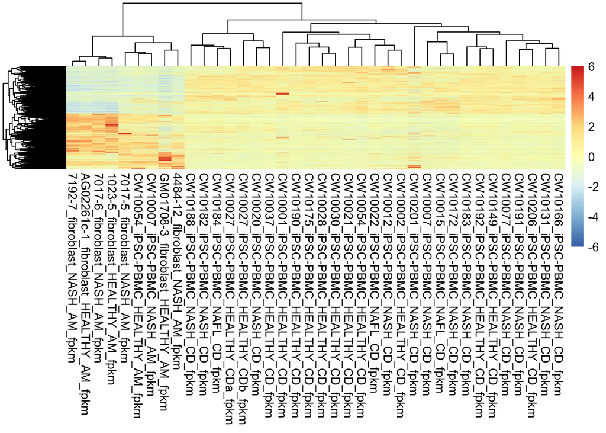

```r
de_fpkm_values = results[which(results[,"adjPVal_BH__fibroblast_vs_pbmc_baseline"] <=0.05), grep ("_fpkm", colnames(results))]
pheatmap(de_fpkm_values,
         , width=HEATMAP_WIDTH, height=HEATMAP_HEIGHT
         , scale="row"  # actually scale each row
         #, clustering_distance_rows="correlation" # or: euclidean
         , clustering_distance_cols="correlation"
         , clustering_method="complete"
         , display_numbers=FALSE
        , border_color="#00000000" # note: the last two digits here are the alpha channel/ transparency
         , show_rownames=FALSE, show_colnames = TRUE
         #, annotation = annotation
         , fontsize_row=3.5)
```

Gene Ontology enrichment

```r
#setup gene DE for GOplot package later
GOplot_genes = results [grep ("__fibroblast_vs_pbmc_baseline",colnames(results))]
colnames(GOplot_genes) = c("logFC", "logCPM", "LR", "Pvalue", "BH")
GOplot_genes["ID"] = results[,"ensembl_gene_id"]
colnames(GOplot_genes)
```

```
## [1] "logFC"  "logCPM" "LR"     "Pvalue" "BH"     "ID"
```

```r
length(unique(GOplot_genes$ID))
```

```
## [1] 26281
```

```r
GOplot_genes = GOplot_genes[, c("ID", "logFC")]

geneIDs = results[,"ensembl_gene_id"]
inUniverse = geneIDs %in%  results[,"ensembl_gene_id"]
inSelection = geneIDs %in% results[which(results[,"adjPVal_BH__fibroblast_vs_pbmc_baseline"] <=0.05),"ensembl_gene_id"]
alg <- factor( as.integer( inSelection[inUniverse] ) )
names(alg) <- geneIDs[inUniverse]
head(alg)
```

```
## ENSG00000223972 ENSG00000227232 ENSG00000278267 ENSG00000243485
##               0               0               0               0
## ENSG00000237613 ENSG00000238009
##               0               0
## Levels: 0 1
```

```r
onts = c( "MF", "BP", "CC" )
tab = as.list(onts)
names(tab) = onts
GOplot_terms=list()
  for(i in 1:3) {
    ## prepare data
    tgd <- new( "topGOdata", ontology=onts[i], allGenes = alg, nodeSize=5,
                 annot=annFUN.org, mapping="org.Hs.eg.db", ID = "ensembl" )

    ## run tests
    resultTopGO.elim <- runTest(tgd, algorithm = "elim", statistic = "Fisher" )
    resultTopGO.classic <- runTest(tgd, algorithm = "classic", statistic = "Fisher" )

    ## look at results
    tab[[i]] <- GenTable( tgd, Fisher.elim = resultTopGO.elim,
        Fisher.classic = resultTopGO.classic,
        orderBy = "Fisher.classic" , topNodes = 200)

    #convert list to dataframe
    allGO = genesInTerm(tgd, tab[[i]][,"GO.ID"])
    test = ldply (lapply(allGO, function(x) paste(x, collapse=",")), data.frame)
    #match(test$.id, tab[[i]][, "GO.ID"]) #check to make sure they rows match
    GOplot_terms[[i]] = data.frame(onts[i], tab[[i]], test, stringsAsFactors = FALSE)
    GOplot_terms[[i]][, "Fisher.elim"] = as.numeric(as.character(GOplot_terms[[i]][, "Fisher.elim"]))
    GOplot_terms[[i]][, "Fisher.elim.BH"] = p.adjust(GOplot_terms[[i]][, "Fisher.elim"], method="BH")
    GOplot_terms[[i]] = GOplot_terms[[i]][, c("onts.i.", "GO.ID", "Term", "Fisher.elim.BH", "X..i..")]
    colnames(GOplot_terms[[i]]) = c("Category", "ID", "Term",  "adj_pval", "Genes")
  }
```

[output not shown]

[output not shown]

[output not shown]

[output not shown]

[output not shown]

[output not shown]

[output not shown]

[output not shown]

[output not shown]

[output not shown]

[output not shown]

[output not shown]

[output not shown]

[output not shown]

[output not shown]

[output not shown]

[output not shown]

[output not shown]

[output not shown]

[output not shown]

[output not shown]

[output not shown]

[output not shown]

[output not shown]

[output not shown]

[output not shown]

[output not shown]

[output not shown]

[output not shown]

[output not shown]

[output not shown]

[output not shown]

[output not shown]

[output not shown]

[output not shown]

[output not shown]

[output not shown]

[output not shown]

[output not shown]

[output not shown]

[output not shown]

[output not shown]

[output not shown]

[output not shown]

[output not shown]

[output not shown]

[output not shown]

[output not shown]

[output not shown]

[output not shown]

[output not shown]

[output not shown]

[output not shown]

[output not shown]

[output not shown]

[output not shown]

[output not shown]

[output not shown]

[output not shown]

[output not shown]

[output not shown]

[output not shown]

[output not shown]

[output not shown]

[output not shown]

[output not shown]

[output not shown]

[output not shown]

[output not shown]

[output not shown]

[output not shown]

[output not shown]

[output not shown]

[output not shown]

```r
topGOResults <- rbind.fill(tab)
topGOResults2 <- rbind.fill(GOplot_terms)
```

Plot Gene Ontology enrichment results

[figure not shown]

```r
curr_date = format(Sys.time(), "%a_%b_%d_%H_hrs_%M_min_%S_sec_%Y")
write.table(topGOResults2, paste0("~/Downloads/duwaerts_mattis_goresults_", curr_date, ".xls"),  col.names=NA, sep="\t")

# create object to plot
circ <- circle_dat(topGOResults2, data.frame(GOplot_genes))

par(cex=.5,font=2)
par(mar=c(.4,.2,.2,.4), pty='s')
GOBar(circ, display='multiple')
```

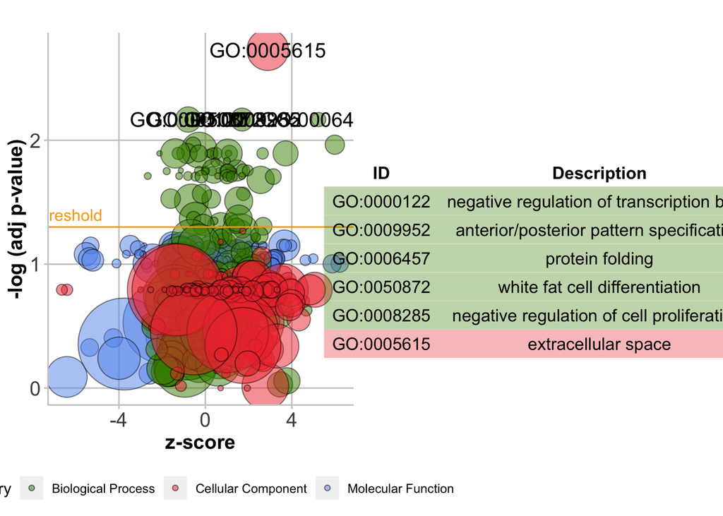

```r
GOBubble(circ, labels = 2)
```